# Weather Prediction & Analysis Report

Zankar Murudkar

## About the Data and What we need.

Our dataset contains information regarding the weather and atmospheric conditions recorded across various locations in Australia over a long period of time.

**Our Goal** is to predict the possibility of Rainfall the next day based on the pre recorded atmospheric conditions and other factors for the day before. Some of the factors include: Location, Date, Temperatures, Wind Speed and Direction, Humidity, Pressure, etc.

## Data Analysis

Now we will load our dataset and run some scripts to gain a little more insight into the data.

We load our **raw** dataset as **rain**

```r
path = "/Users/zankar/Desktop/ML/weatherAUS.csv"
rain <- read.csv(path,header=TRUE,sep=',',stringsAsFactors = F)
```

Checking the dimensions of the dataset.

```r
dim(rain)
```

```
## [1] 145460     23
```

This indicates we have 145460 instances of data and 23 different variables, 22 are independent variables which will be used to predict our dependent Target variable.

Let’s find out the variable column names.

```r
names(rain)
```

```
##  [1] "Date"          "Location"      "MinTemp"       "MaxTemp"
##  [5] "Rainfall"      "Evaporation"   "Sunshine"      "WindGustDir"
##  [9] "WindGustSpeed" "WindDir9am"    "WindDir3pm"    "WindSpeed9am"
## [13] "WindSpeed3pm"  "Humidity9am"   "Humidity3pm"   "Pressure9am"
## [17] "Pressure3pm"   "Cloud9am"      "Cloud3pm"      "Temp9am"
## [21] "Temp3pm"       "RainToday"     "RainTomorrow"
```

Since we are trying to predict whether we will experience rainfall the next day, our **Target** variable is **RainTomorrow**

Checking the head and tail of data.

```r
head(rain)
```

```
##         Date Location MinTemp MaxTemp Rainfall Evaporation Sunshine WindGustDir
## 1 2008-12-01   Albury    13.4    22.9      0.6          NA       NA           W
## 2 2008-12-02   Albury     7.4    25.1      0.0          NA       NA         WNW
## 3 2008-12-03   Albury    12.9    25.7      0.0          NA       NA         WSW
## 4 2008-12-04   Albury     9.2    28.0      0.0          NA       NA          NE
## 5 2008-12-05   Albury    17.5    32.3      1.0          NA       NA           W
## 6 2008-12-06   Albury    14.6    29.7      0.2          NA       NA         WNW
##   WindGustSpeed WindDir9am WindDir3pm WindSpeed9am WindSpeed3pm Humidity9am
## 1            44          W        WNW           20           24          71
## 2            44        NNW        WSW            4           22          44
## 3            46          W        WSW           19           26          38
## 4            24         SE          E           11            9          45
## 5            41        ENE         NW            7           20          82
## 6            56          W          W           19           24          55
##   Humidity3pm Pressure9am Pressure3pm Cloud9am Cloud3pm Temp9am Temp3pm
## 1          22      1007.7      1007.1        8       NA    16.9    21.8
## 2          25      1010.6      1007.8       NA       NA    17.2    24.3
## 3          30      1007.6      1008.7       NA        2    21.0    23.2
## 4          16      1017.6      1012.8       NA       NA    18.1    26.5
## 5          33      1010.8      1006.0        7        8    17.8    29.7
## 6          23      1009.2      1005.4       NA       NA    20.6    28.9
##   RainToday RainTomorrow
## 1        No           No
## 2        No           No
## 3        No           No
## 4        No           No
## 5        No           No
## 6        No           No
```

```r
tail(rain)
```

```
##              Date Location MinTemp MaxTemp Rainfall Evaporation Sunshine
## 145455 2017-06-20    Uluru     3.5    21.8        0          NA       NA
## 145456 2017-06-21    Uluru     2.8    23.4        0          NA       NA
## 145457 2017-06-22    Uluru     3.6    25.3        0          NA       NA
## 145458 2017-06-23    Uluru     5.4    26.9        0          NA       NA
## 145459 2017-06-24    Uluru     7.8    27.0        0          NA       NA
## 145460 2017-06-25    Uluru    14.9      NA        0          NA       NA
##        WindGustDir WindGustSpeed WindDir9am WindDir3pm WindSpeed9am
## 145455           E            31        ESE          E           15
## 145456           E            31         SE        ENE           13
## 145457         NNW            22         SE          N           13
## 145458           N            37         SE        WNW            9
## 145459          SE            28        SSE          N           13
## 145460        <NA>            NA        ESE        ESE           17
##        WindSpeed3pm Humidity9am Humidity3pm Pressure9am Pressure3pm Cloud9am
## 145455           13          59          27      1024.7      1021.2       NA
## 145456           11          51          24      1024.6      1020.3       NA
## 145457            9          56          21      1023.5      1019.1       NA
## 145458            9          53          24      1021.0      1016.8       NA
## 145459            7          51          24      1019.4      1016.5        3
## 145460           17          62          36      1020.2      1017.9        8
##        Cloud3pm Temp9am Temp3pm RainToday RainTomorrow
## 145455       NA     9.4    20.9        No           No
## 145456       NA    10.1    22.4        No           No
## 145457       NA    10.9    24.5        No           No
## 145458       NA    12.5    26.1        No           No
## 145459        2    15.1    26.0        No           No
## 145460        8    15.0    20.9        No         <NA>
```

We have a mix of numerical as well as categorical values. Inspecting from the head and tail, we seem to have significant number of NA values.

## NA Values in data

We check number of NA values present in each column and remove the rows with present NA values.

```r
sapply(rain, function(x) sum(is.na(x)))
```

```
##          Date      Location       MinTemp       MaxTemp      Rainfall
##             0             0          1485          1261          3261
##   Evaporation      Sunshine   WindGustDir WindGustSpeed    WindDir9am
##         62790         69835         10326         10263         10566
##    WindDir3pm  WindSpeed9am  WindSpeed3pm   Humidity9am   Humidity3pm
##          4228          1767          3062          2654          4507
##   Pressure9am   Pressure3pm      Cloud9am      Cloud3pm       Temp9am
##         15065         15028         55888         59358          1767
##       Temp3pm     RainToday  RainTomorrow
##          3609          3261          3267
```

```r
weather <- na.omit(rain)
sapply(weather,function(x) sum(is.na(x)))
```

```
##          Date      Location       MinTemp       MaxTemp      Rainfall
##             0             0             0             0             0
##   Evaporation      Sunshine   WindGustDir WindGustSpeed    WindDir9am
##             0             0             0             0             0
##    WindDir3pm  WindSpeed9am  WindSpeed3pm   Humidity9am   Humidity3pm
##             0             0             0             0             0
##   Pressure9am   Pressure3pm      Cloud9am      Cloud3pm       Temp9am
##             0             0             0             0             0
##       Temp3pm     RainToday  RainTomorrow
##             0             0             0
```

Our data is now free of NA values. Let’s check the dimension, head and tail of the data again.

```r
dim(weather)
```

```
## [1] 56420    23
```

```r
head(weather)
```

```
##            Date Location MinTemp MaxTemp Rainfall Evaporation Sunshine
## 6050 2009-01-01    Cobar    17.9    35.2        0        12.0     12.3
## 6051 2009-01-02    Cobar    18.4    28.9        0        14.8     13.0
## 6053 2009-01-04    Cobar    19.4    37.6        0        10.8     10.6
## 6054 2009-01-05    Cobar    21.9    38.4        0        11.4     12.2
## 6055 2009-01-06    Cobar    24.2    41.0        0        11.2      8.4
## 6056 2009-01-07    Cobar    27.1    36.1        0        13.0      0.0
##      WindGustDir WindGustSpeed WindDir9am WindDir3pm WindSpeed9am WindSpeed3pm
## 6050         SSW            48        ENE         SW            6           20
## 6051           S            37        SSE        SSE           19           19
## 6053         NNE            46        NNE        NNW           30           15
## 6054         WNW            31        WNW        WSW            6            6
## 6055         WNW            35         NW        WNW           17           13
## 6056           N            43          N        WNW            7           20
##      Humidity9am Humidity3pm Pressure9am Pressure3pm Cloud9am Cloud3pm Temp9am
## 6050          20          13      1006.3      1004.4        2        5    26.6
## 6051          30           8      1012.9      1012.1        1        1    20.3
## 6053          42          22      1012.3      1009.2        1        6    28.7
## 6054          37          22      1012.7      1009.1        1        5    29.1
## 6055          19          15      1010.7      1007.4        1        6    33.6
## 6056          26          19      1007.7      1007.4        8        8    30.7
##      Temp3pm RainToday RainTomorrow
## 6050    33.4        No           No
## 6051    27.0        No           No
## 6053    34.9        No           No
## 6054    35.6        No           No
## 6055    37.6        No           No
## 6056    34.3        No           No
```

```r
tail(weather)
```

```
##              Date Location MinTemp MaxTemp Rainfall Evaporation Sunshine
## 142298 2017-06-19   Darwin    21.9    33.0        0         5.2     10.9
## 142299 2017-06-20   Darwin    19.3    33.4        0         6.0     11.0
## 142300 2017-06-21   Darwin    21.2    32.6        0         7.6      8.6
## 142301 2017-06-22   Darwin    20.7    32.8        0         5.6     11.0
## 142302 2017-06-23   Darwin    19.5    31.8        0         6.2     10.6
## 142303 2017-06-24   Darwin    20.2    31.7        0         5.6     10.7
##        WindGustDir WindGustSpeed WindDir9am WindDir3pm WindSpeed9am
## 142298           E            44         SE        ENE           15
## 142299         ENE            35         SE         NE            9
## 142300           E            37         SE         SE           13
## 142301           E            33          E          W           17
## 142302         ESE            26         SE        NNW            9
## 142303         ENE            30        ENE        NNW           15
##        WindSpeed3pm Humidity9am Humidity3pm Pressure9am Pressure3pm Cloud9am
## 142298           19          43          28      1014.6      1010.6        1
## 142299           20          63          32      1013.9      1010.5        0
## 142300           11          56          28      1014.6      1011.2        7
## 142301           11          46          23      1015.3      1011.8        0
## 142302           17          62          58      1014.9      1010.7        1
## 142303            7          73          32      1013.9      1009.7        6
##        Cloud3pm Temp9am Temp3pm RainToday RainTomorrow
## 142298        1    25.1    32.7        No           No
## 142299        1    24.5    32.3        No           No
## 142300        0    24.8    32.0        No           No
## 142301        0    24.8    32.1        No           No
## 142302        1    24.8    29.2        No           No
## 142303        5    25.4    31.0        No           No
```

## Type of Variables

Checking the type of each Column Variable class.

```r
str(weather)
```

```
## 'data.frame':    56420 obs. of  23 variables:
##  $ Date         : chr  "2009-01-01" "2009-01-02" "2009-01-04" "2009-01-05" ...
##  $ Location     : chr  "Cobar" "Cobar" "Cobar" "Cobar" ...
##  $ MinTemp      : num  17.9 18.4 19.4 21.9 24.2 27.1 23.3 16.1 19 19.7 ...
##  $ MaxTemp      : num  35.2 28.9 37.6 38.4 41 36.1 34 34.2 35.5 35.5 ...
##  $ Rainfall     : num  0 0 0 0 0 0 0 0 0 0 ...
##  $ Evaporation  : num  12 14.8 10.8 11.4 11.2 13 9.8 14.6 12 11 ...
##  $ Sunshine     : num  12.3 13 10.6 12.2 8.4 0 12.6 13.2 12.3 12.7 ...
##  $ WindGustDir  : chr  "SSW" "S" "NNE" "WNW" ...
##  $ WindGustSpeed: int  48 37 46 31 35 43 41 37 48 41 ...
##  $ WindDir9am   : chr  "ENE" "SSE" "NNE" "WNW" ...
##  $ WindDir3pm   : chr  "SW" "SSE" "NNW" "WSW" ...
##  $ WindSpeed9am : int  6 19 30 6 17 7 17 15 30 15 ...
##  $ WindSpeed3pm : int  20 19 15 6 13 20 19 6 9 17 ...
##  $ Humidity9am  : int  20 30 42 37 19 26 33 25 46 61 ...
##  $ Humidity3pm  : int  13 8 22 22 15 19 15 9 28 14 ...
##  $ Pressure9am  : num  1006 1013 1012 1013 1011 ...
##  $ Pressure3pm  : num  1004 1012 1009 1009 1007 ...
##  $ Cloud9am     : int  2 1 1 1 1 8 3 1 1 1 ...
##  $ Cloud3pm     : int  5 1 6 5 6 8 1 1 5 5 ...
##  $ Temp9am      : num  26.6 20.3 28.7 29.1 33.6 30.7 25 20.7 23.4 24 ...
##  $ Temp3pm      : num  33.4 27 34.9 35.6 37.6 34.3 31.5 32.8 33.3 33.6 ...
##  $ RainToday    : chr  "No" "No" "No" "No" ...
##  $ RainTomorrow : chr  "No" "No" "No" "No" ...
##  - attr(*, "na.action")= 'omit' Named int [1:89040] 1 2 3 4 5 6 7 8 9 10 ...
##   ..- attr(*, "names")= chr [1:89040] "1" "2" "3" "4" ...
```

**Date** is in the year/month/day format, the day and year seem to be irrelevant for our prediction but the month can be a relevant factor. We will extract only the month from the Date column which will result in 12 Categorical values from 1-12 indicating months.

```r
weather$Date <- as.Date(as.character(weather$Date))
weather$Date <- strftime(weather$Date,"%m")
table(weather$Date)
```

```
##
##   01   02   03   04   05   06   07   08   09   10   11   12
## 5267 4229 5174 4422 4896 4565 4709 4728 4638 4811 4717 4264
```

As seen earlier with **str()**, we have numerical as well as character values. Character values may be a hindrance while performing numerical operations on the data like calculating distances, correlation, etc. Therefore we will convert our Character values to numeric.

```r
weather$Location <- as.numeric(as.factor(weather$Location))
weather$WindGustDir <- as.numeric(as.factor(weather$WindGustDir))
weather$WindDir9am <- as.numeric(as.factor(weather$WindDir9am))
weather$WindDir3pm <- as.numeric(as.factor(weather$WindDir3pm))
weather$RainTomorrow <-ifelse(weather$RainTomorrow=='Yes',1,0)
weather$RainToday <-ifelse(weather$RainToday=='Yes',1,0)
weather$Date <- as.numeric(as.factor(weather$Date))
str(weather)
```

```
## 'data.frame':    56420 obs. of  23 variables:
##  $ Date         : num  1 1 1 1 1 1 1 1 1 1 ...
##  $ Location     : num  5 5 5 5 5 5 5 5 5 5 ...
##  $ MinTemp      : num  17.9 18.4 19.4 21.9 24.2 27.1 23.3 16.1 19 19.7 ...
##  $ MaxTemp      : num  35.2 28.9 37.6 38.4 41 36.1 34 34.2 35.5 35.5 ...
##  $ Rainfall     : num  0 0 0 0 0 0 0 0 0 0 ...
##  $ Evaporation  : num  12 14.8 10.8 11.4 11.2 13 9.8 14.6 12 11 ...
##  $ Sunshine     : num  12.3 13 10.6 12.2 8.4 0 12.6 13.2 12.3 12.7 ...
##  $ WindGustDir  : num  12 9 6 15 15 4 12 10 2 5 ...
##  $ WindGustSpeed: int  48 37 46 31 35 43 41 37 48 41 ...
##  $ WindDir9am   : num  2 11 6 15 8 4 9 10 2 6 ...
##  $ WindDir3pm   : num  13 11 7 16 15 15 11 9 16 16 ...
##  $ WindSpeed9am : int  6 19 30 6 17 7 17 15 30 15 ...
##  $ WindSpeed3pm : int  20 19 15 6 13 20 19 6 9 17 ...
##  $ Humidity9am  : int  20 30 42 37 19 26 33 25 46 61 ...
##  $ Humidity3pm  : int  13 8 22 22 15 19 15 9 28 14 ...
##  $ Pressure9am  : num  1006 1013 1012 1013 1011 ...
##  $ Pressure3pm  : num  1004 1012 1009 1009 1007 ...
##  $ Cloud9am     : int  2 1 1 1 1 8 3 1 1 1 ...
##  $ Cloud3pm     : int  5 1 6 5 6 8 1 1 5 5 ...
##  $ Temp9am      : num  26.6 20.3 28.7 29.1 33.6 30.7 25 20.7 23.4 24 ...
##  $ Temp3pm      : num  33.4 27 34.9 35.6 37.6 34.3 31.5 32.8 33.3 33.6 ...
##  $ RainToday    : num  0 0 0 0 0 0 0 0 0 0 ...
##  $ RainTomorrow : num  0 0 0 0 0 0 0 0 0 0 ...
##  - attr(*, "na.action")= 'omit' Named int [1:89040] 1 2 3 4 5 6 7 8 9 10 ...
##   ..- attr(*, "names")= chr [1:89040] "1" "2" "3" "4" ...
```

## Looking for Constant Variables

Let’s check the distribution of values across all our variables.

```r
apply(weather,2,table)
```

[output not shown]

[output cut: 577 more lines]

```
##   12    9   13    7   12    9   12   10   10   13    4   10    8    8    9    2
## 42.2 42.3 42.4 42.5 42.6 42.7 42.9   43 43.1 43.2 43.3 43.4 43.6 43.7 43.9 44.1
##    5    6   11    6    6    4    5    6    1    1    3    2    3    1    1    2
## 44.5 44.7 44.8 44.9 45.2 45.3 45.4 45.8 46.1
##    1    1    1    1    1    1    1    2    3
##
## $RainToday
##
##     0     1
## 43958 12462
##
## $RainTomorrow
##
##     0     1
## 43993 12427
```

Distribution of values did not show any constant features, we will still check and remove if we have any constant features.

```r
isConstant<-function(x) length(names(table(x)))<2
apply(weather,2,isConstant)
```

```
##          Date      Location       MinTemp       MaxTemp      Rainfall
##         FALSE         FALSE         FALSE         FALSE         FALSE
##   Evaporation      Sunshine   WindGustDir WindGustSpeed    WindDir9am
##         FALSE         FALSE         FALSE         FALSE         FALSE
##    WindDir3pm  WindSpeed9am  WindSpeed3pm   Humidity9am   Humidity3pm
##         FALSE         FALSE         FALSE         FALSE         FALSE
##   Pressure9am   Pressure3pm      Cloud9am      Cloud3pm       Temp9am
##         FALSE         FALSE         FALSE         FALSE         FALSE
##       Temp3pm     RainToday  RainTomorrow
##         FALSE         FALSE         FALSE
```

The result indicates we do not have any constant features.

## Variable Correlation

Multiple Correlated attributes may influence the prediction values. We will check for Correlation and remove attributes which may be highly correlated to any other attributes.

Creating a Correlation matrix between all Predictor attributes.

```r
cor(weather)
```

```
##                       Date     Location     MinTemp      MaxTemp    Rainfall
## Date           1.000000000 -0.010701031 -0.19140505 -0.160873406 -0.03349789
## Location      -0.010701031  1.000000000 -0.15595372 -0.147499890 -0.04331366
## MinTemp       -0.191405051 -0.155953718  1.00000000  0.749687250  0.11079984
## MaxTemp       -0.160873406 -0.147499890  0.74968725  1.000000000 -0.06998069
## Rainfall      -0.033497892 -0.043313655  0.11079984 -0.069980691  1.00000000
## Evaporation   -0.045118351 -0.011508676  0.50676430  0.650964414 -0.07723881
## Sunshine       0.030539353 -0.033940981  0.07608699  0.463912795 -0.24637932
## WindGustDir    0.031924681  0.099918499 -0.19055390 -0.244508128  0.06735049
## WindGustSpeed  0.043543855  0.085603399  0.11805376  0.035530989  0.10630832
## WindDir9am     0.009012108 -0.033247466 -0.05831022 -0.246042841  0.09897990
## WindDir3pm     0.021760590  0.085732167 -0.19412338 -0.200749852  0.05922874
## WindSpeed9am   0.048617915  0.061992674  0.10852150 -0.008171393  0.05058411
## WindSpeed3pm   0.055328005  0.099760846  0.13727349  0.012265737  0.04411181
## Humidity9am   -0.092246873  0.107279106 -0.17499134 -0.495781368  0.26362527
## Humidity3pm   -0.026354238  0.026146905  0.07082706 -0.448115511  0.27762523
## Pressure9am    0.058443390  0.088566846 -0.47566107 -0.350979564 -0.18060599
## Pressure3pm    0.046966543  0.120987202 -0.49557702 -0.451690871 -0.13730196
## Cloud9am      -0.006726683  0.018257247  0.10617712 -0.263633929  0.21716854
## Cloud3pm      -0.010734634  0.010527096  0.04217283 -0.257751745  0.19143323
## Temp9am       -0.125117995 -0.194448734  0.90629478  0.893386952  0.01371317
## Temp3pm       -0.168431177 -0.148955293  0.72722205  0.984841408 -0.07462670
## RainToday      0.002767274 -0.006036619  0.04895331 -0.221810044  0.55051509
## RainTomorrow   0.001046055 -0.005099552  0.08742777 -0.147466714  0.25434170
##               Evaporation    Sunshine  WindGustDir WindGustSpeed   WindDir9am
## Date          -0.04511835  0.03053935  0.031924681  0.0435438548  0.009012108
## Location      -0.01150868 -0.03394098  0.099918499  0.0856033989 -0.033247466
## MinTemp        0.50676430  0.07608699 -0.190553904  0.1180537609 -0.058310216
## MaxTemp        0.65096441  0.46391279 -0.244508128  0.0355309885 -0.246042841
## Rainfall      -0.07723881 -0.24637932  0.067350493  0.1063083184  0.098979901
## Evaporation    1.00000000  0.36924973 -0.104655845  0.2095661990 -0.130682702
## Sunshine       0.36924973  1.00000000 -0.087354614 -0.0524221569 -0.108688761
## WindGustDir   -0.10465584 -0.08735461  1.000000000  0.1196776000  0.430859474
## WindGustSpeed  0.20956620 -0.05242216  0.119677600  1.0000000000  0.023396209
## WindDir9am    -0.13068270 -0.10868876  0.430859474  0.0233962087  1.000000000
## WindDir3pm    -0.07235734 -0.05079518  0.619891815  0.1136874967  0.320817566
## WindSpeed9am   0.19315402 -0.01384163  0.007951591  0.6088518373 -0.007907017
## WindSpeed3pm   0.12434480  0.02920010  0.085679121  0.6852363743  0.094271263
## Humidity9am   -0.55423190 -0.50034265  0.096058678 -0.1934104031  0.165934875
## Humidity3pm   -0.42243577 -0.62929873  0.053718569 -0.0426528147  0.189645066
```

[output cut: 65 more lines]

```
## WindGustSpeed -0.0003821692  0.146275565  0.233158169
## WindDir9am    -0.2529510905  0.181461086  0.035991956
## WindDir3pm    -0.2140436246  0.128208724  0.032202530
## WindSpeed9am  -0.0183573986  0.083124599  0.083904488
## WindSpeed3pm  -0.0094357893  0.085626549  0.088861671
## Humidity9am   -0.4877579791  0.379451219  0.271032960
## Humidity3pm   -0.4972452866  0.385439817  0.455357637
## Pressure9am   -0.3107736568 -0.186847694 -0.254815656
## Pressure3pm   -0.4213178644 -0.104102757 -0.230417506
## Cloud9am      -0.2812133809  0.297794033  0.323972381
## Cloud3pm      -0.2972300085  0.272034318  0.388574211
## Temp9am        0.8706196503 -0.096946010 -0.018179123
## Temp3pm        1.0000000000 -0.228515128 -0.183586164
## RainToday     -0.2285151281  1.000000000  0.309098228
## RainTomorrow  -0.1835861640  0.309098228  1.000000000
```

Going through the matrix, we can see that Correlation values between MaxTemp,MinTemp,Temp9am, Temp3pm is very high. Similarly we have high Correlation between Pressure9am and Pressure3pm.

Let’s plot a graph for the correlation values.

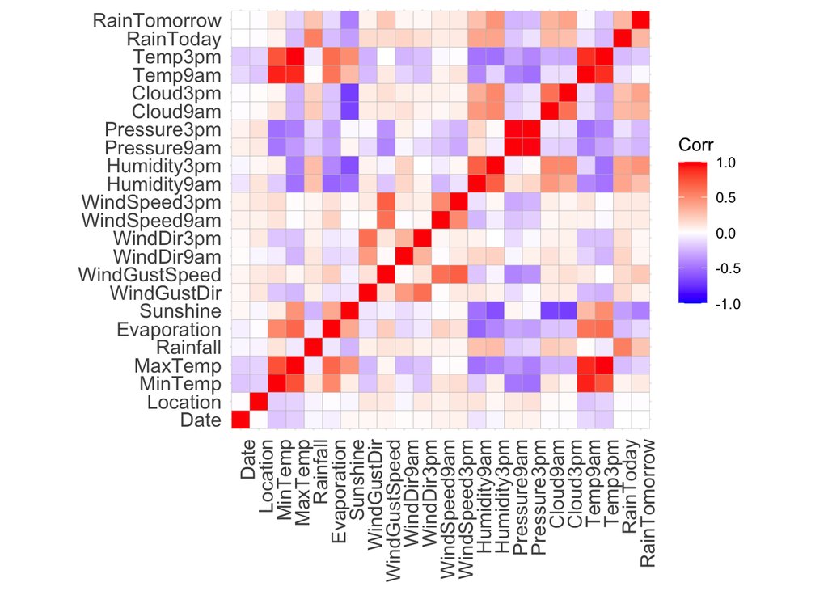

```r
if(!require(ggcorrplot))install.packages('ggcorrplot')
library(ggcorrplot)
p<-ggcorrplot(cor(weather))
p + theme(axis.text.x = element_text(angle = 90))
```

Looking for methods to understand Correlation between Predictors efficiently, I came across a very helpful git repository which includes a number of functions for Visualizations and plots. Below we will use one of the functions from mentioned repository to get top 10-15 correlated variables. I have commented the install script.

```r
#devtools::install_github("laresbernardo/lares")
library(lares)
corr_cross(weather, # name of dataset
           max_pvalue = 0.05, # display only significant correlations (at 5% level)
           top = 15 # display top 15 couples of variables (by correlation coefficient)
)
```

```
## Returning only the top 15. You may override with the 'top' argument
```

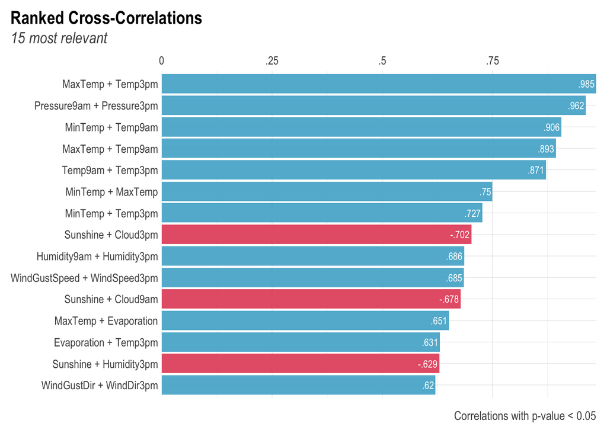

## Removing Highly Correlated Variables

```r
weather2<-subset(weather, select = -c(Temp3pm,Temp9am,Pressure9am))
```

Let’s plot the Correlation again to see if we have any other highly correlated pairs.

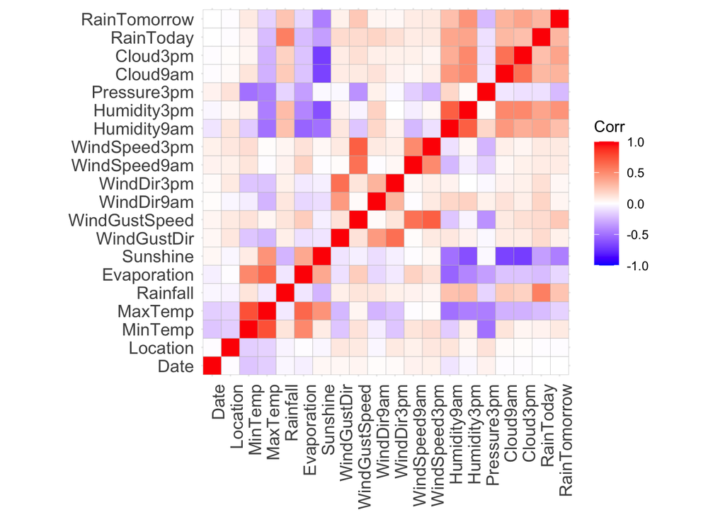

```r
p2<-ggcorrplot(cor(weather2))
p2 + theme(axis.text.x = element_text(angle = 90))
```

```r
corr_cross(weather2, # name of dataset
           max_pvalue = 0.05, # display only significant correlations (at 5% level)
           top = 15 # display top 15 couples of variables (by correlation coefficient)
)
```

```
## Returning only the top 15. You may override with the 'top' argument
```

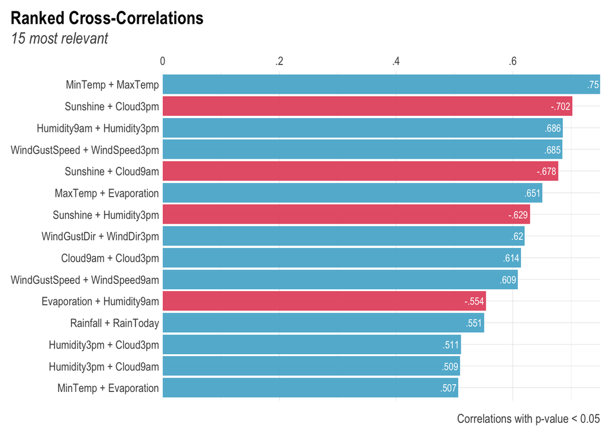

We have mostly removed Correlation above 0.8

## RandomForest to determine Important features

We will run the Random Forest algorithm on our data to find the importance of each predictor.

```r
require(randomForest)
weather2$RainTomorrow<-as.factor(weather2$RainTomorrow)#converts numerical to categorial for rf
class(weather2$RainTomorrow)
```

```
## [1] "factor"
```

```r
weather.rf<-randomForest(RainTomorrow~.,data=weather2)
importance(weather.rf)
```

```
##               MeanDecreaseGini
## Date                  532.4861
## Location              644.7228
## MinTemp               977.3796
## MaxTemp               963.9555
## Rainfall             1027.2571
## Evaporation           812.6262
## Sunshine             2265.0966
## WindGustDir           574.2850
## WindGustSpeed        1203.6159
## WindDir9am            593.7547
## WindDir3pm            585.9166
## WindSpeed9am          652.6597
## WindSpeed3pm          673.5869
## Humidity9am           998.6383
## Humidity3pm          3312.9521
## Pressure3pm          1586.2982
## Cloud9am              594.7641
## Cloud3pm             1043.4426
## RainToday             335.1493
```

```r
require(caret)
varImp(weather.rf)
```

```
##                 Overall
## Date           532.4861
## Location       644.7228
## MinTemp        977.3796
## MaxTemp        963.9555
## Rainfall      1027.2571
## Evaporation    812.6262
## Sunshine      2265.0966
## WindGustDir    574.2850
## WindGustSpeed 1203.6159
## WindDir9am     593.7547
## WindDir3pm     585.9166
## WindSpeed9am   652.6597
## WindSpeed3pm   673.5869
## Humidity9am    998.6383
## Humidity3pm   3312.9521
## Pressure3pm   1586.2982
## Cloud9am       594.7641
## Cloud3pm      1043.4426
## RainToday      335.1493
```

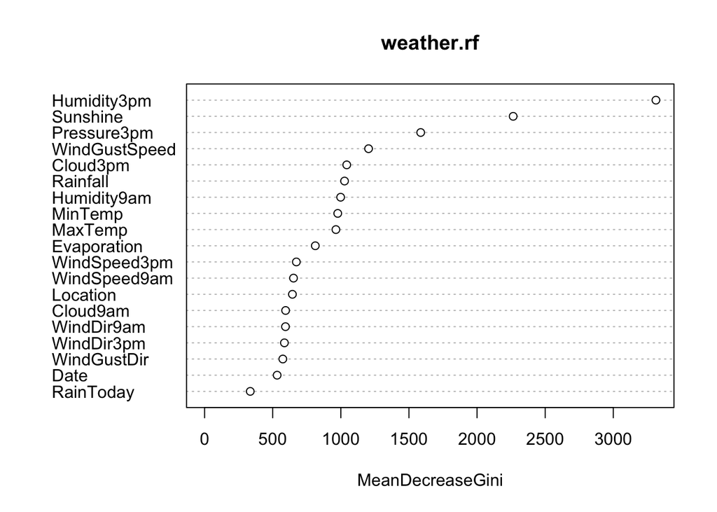

```r
varImpPlot(weather.rf)
```

Change Target variable back to numeric.

```r
weather2$RainTomorrow<-as.numeric(weather2$RainTomorrow)
weather2$RainTomorrow <-ifelse(weather$RainTomorrow==1,1,0)
```

We will now find the top variables with most importance.

```r
importanceOrder=order(-weather.rf$importance)
names=rownames(weather.rf$importance)[importanceOrder][1:15]
names
```

```
##  [1] "Humidity3pm"   "Sunshine"      "Pressure3pm"   "WindGustSpeed"
##  [5] "Cloud3pm"      "Rainfall"      "Humidity9am"   "MinTemp"
##  [9] "MaxTemp"       "Evaporation"   "WindSpeed3pm"  "WindSpeed9am"
## [13] "Location"      "Cloud9am"      "WindDir9am"
```

Create a data frame with **Top 15 Predictors** based on Importance.

```r
impweather<-weather2[,names]
impweather$RainTomorrow <- weather2$RainTomorrow

dim(impweather)
```

```
## [1] 56420    16
```

```r
head(impweather)
```

```
##      Humidity3pm Sunshine Pressure3pm WindGustSpeed Cloud3pm Rainfall
## 6050          13     12.3      1004.4            48        5        0
## 6051           8     13.0      1012.1            37        1        0
## 6053          22     10.6      1009.2            46        6        0
## 6054          22     12.2      1009.1            31        5        0
## 6055          15      8.4      1007.4            35        6        0
## 6056          19      0.0      1007.4            43        8        0
##      Humidity9am MinTemp MaxTemp Evaporation WindSpeed3pm WindSpeed9am Location
## 6050          20    17.9    35.2        12.0           20            6        5
## 6051          30    18.4    28.9        14.8           19           19        5
## 6053          42    19.4    37.6        10.8           15           30        5
## 6054          37    21.9    38.4        11.4            6            6        5
## 6055          19    24.2    41.0        11.2           13           17        5
## 6056          26    27.1    36.1        13.0           20            7        5
##      Cloud9am WindDir9am RainTomorrow
## 6050        2          2            0
## 6051        1         11            0
## 6053        1          6            0
## 6054        1         15            0
## 6055        1          8            0
## 6056        8          4            0
```

## Binary or MultiClass Classification ?

```r
classLabels<-table(impweather$RainTomorrow)
print(classLabels)
```

```
##
##     0     1
## 43993 12427
```

```r
names(classLabels)
```

```
## [1] "0" "1"
```

```r
length(names(classLabels))
```

```
## [1] 2
```

```r
ifelse(length(names(classLabels))==2,"binary classification", "multi-class classification")
```

```
## [1] "binary classification"
```

We have **Binary Classification** at hand. We will perform **Logistic Regression** and **SVM** which are suitable for Binary Classification along with **Naive Bayes, Multinom & KNN**

## Dividing the data

We now divide the dataset as follows: 10% for Variance Estimation 90% for Generalization, Training and Testing

**For Important Predictors data**

```r
set.seed(43)
varidx<-sample(1:nrow(impweather),0.10*nrow(impweather),replace=F)
impweather2<-impweather[-varidx,]
vardata<-impweather[varidx,]
```

**Dividing data into training and testing data** 70% for training, 30% for testing

```r
set.seed(43)
tstidx<-sample(1:nrow(impweather2),0.30*nrow(impweather2),replace=F)
trdata<-impweather2[-tstidx,]
tsdata<-impweather2[tstidx,]
```

## Classifiers

We conclude the Exploratory data analysis and use the acquired dataset with minimum correlation between variables and selected important variables. The dataset will be tested on the below mentioned classifiers: 1) Logistic Regression 2) SVM 3) Naive Bayes 4) KNN 5) Multinomial Logistic Regression

We will find the Test Accuracies from the above mentioned Classifiers and compare them.

## Logistic Regression

Let’s start with Logistic Regression.

First setup all the required libraries.

```r
library(plotly)
if(!require(stringr))install.packages('stringr')
library(stringr)
if(!require(car))install.packages('car')
library(car)
if(!require(e1071))install.packages('e1071')
library(e1071)
require(e1071)
if(!require(caret))install.packages('caret')
library(caret)
require(caret)
if(!require(pROC))install.packages('pROC')
library(pROC)
if(!require(ROCR))install.packages('ROCR')
library(ROCR)
```

Generalization Phase. We use the Logistic Regression model on our dataset to find and improve model accuracies.

```r
glm_model<-glm(RainTomorrow~.,data=impweather2, family='binomial')
summary_glm_model<-summary(glm_model)
coef_summary_glm_model<-coef(summary_glm_model)
```

Findind and selecting Predictors with Coefficient values less than 0.05

```r
coef_summary_glm_model
```

```
##                   Estimate  Std. Error    z value      Pr(>|z|)
## (Intercept)   62.025444013 2.548448966  24.338507 7.672509e-131
## Humidity3pm    0.057249242 0.001290795  44.351926  0.000000e+00
## Sunshine      -0.149473864 0.006314707 -23.670751 7.217587e-124
## Pressure3pm   -0.067397942 0.002468717 -27.300801 4.149676e-164
## WindGustSpeed  0.058322319 0.001620321  35.994306 1.026976e-283
## Cloud3pm       0.107635481 0.008502791  12.658842  9.996320e-37
## Rainfall       0.021044620 0.002014030  10.449009  1.480639e-25
## Humidity9am    0.003087544 0.001261261   2.447982  1.436587e-02
## MinTemp       -0.035641427 0.005238452  -6.803809  1.018888e-11
## MaxTemp        0.052739940 0.005486921   9.611936  7.119717e-22
## Evaporation   -0.028820811 0.006137346  -4.695973  2.653409e-06
## WindSpeed3pm  -0.025818499 0.002282049 -11.313736  1.122082e-29
## WindSpeed9am  -0.014737869 0.002197647  -6.706203  1.997539e-11
## Location      -0.004078206 0.002045966  -1.993291  4.622963e-02
## Cloud9am      -0.023005091 0.007757045  -2.965703  3.019919e-03
## WindDir9am    -0.011540967 0.003158261  -3.654215  2.579697e-04
```

```r
coef_summary_glm_model[,4]<0.05
```

```
##   (Intercept)   Humidity3pm      Sunshine   Pressure3pm WindGustSpeed
##          TRUE          TRUE          TRUE          TRUE          TRUE
##      Cloud3pm      Rainfall   Humidity9am       MinTemp       MaxTemp
##          TRUE          TRUE          TRUE          TRUE          TRUE
##   Evaporation  WindSpeed3pm  WindSpeed9am      Location      Cloud9am
##          TRUE          TRUE          TRUE          TRUE          TRUE
##    WindDir9am
##          TRUE
```

```r
row_names<-row.names(coef_summary_glm_model[coef_summary_glm_model[,4]<0.05,])
row_names
```

```
##  [1] "(Intercept)"   "Humidity3pm"   "Sunshine"      "Pressure3pm"
##  [5] "WindGustSpeed" "Cloud3pm"      "Rainfall"      "Humidity9am"
##  [9] "MinTemp"       "MaxTemp"       "Evaporation"   "WindSpeed3pm"
## [13] "WindSpeed9am"  "Location"      "Cloud9am"      "WindDir9am"
```

```r
summary_glm_model$aic
```

```
## [1] 34353.86
```

```r
summary_glm_model$null.deviance
```

```
## [1] 53586.1
```

```r
summary_glm_model$deviance
```

```
## [1] 34321.86
```

```r
ifelse(summary_glm_model$deviance<summary_glm_model$null.deviance,"model has improved","model has not helped")
```

```
## [1] "model has improved"
```

Create a formula string with above found Predictors with Coefficient values less than 0.05

```r
formularhs <- paste(row.names(coef_summary_glm_model[coef_summary_glm_model[,4]<0.05,]),collapse='+')
formularhs
```

```
## [1] "(Intercept)+Humidity3pm+Sunshine+Pressure3pm+WindGustSpeed+Cloud3pm+Rainfall+Humidity9am+MinTemp+MaxTemp+Evaporation+WindSpeed3pm+WindSpeed9am+Location+Cloud9am+WindDir9am"
```

```r
library(stringr)
formularhs <- str_extract(formularhs, "Humidity3pm+(?s)(.*$)")

formulastr<-paste('RainTomorrow~',formularhs,sep='')
formulastr
```

```
## [1] "RainTomorrow~Humidity3pm+Sunshine+Pressure3pm+WindGustSpeed+Cloud3pm+Rainfall+Humidity9am+MinTemp+MaxTemp+Evaporation+WindSpeed3pm+WindSpeed9am+Location+Cloud9am+WindDir9am"
```

Using the formula string in the glm model.

```r
model2<-glm(formulastr,data=impweather2,family='binomial')
summ_model2<-summary(model2)
coef_summ_model2<-coef(summ_model2)
coef_summ_model2
```

```
##                   Estimate  Std. Error    z value      Pr(>|z|)
## (Intercept)   62.025444013 2.548448966  24.338507 7.672509e-131
## Humidity3pm    0.057249242 0.001290795  44.351926  0.000000e+00
## Sunshine      -0.149473864 0.006314707 -23.670751 7.217587e-124
## Pressure3pm   -0.067397942 0.002468717 -27.300801 4.149676e-164
## WindGustSpeed  0.058322319 0.001620321  35.994306 1.026976e-283
## Cloud3pm       0.107635481 0.008502791  12.658842  9.996320e-37
## Rainfall       0.021044620 0.002014030  10.449009  1.480639e-25
## Humidity9am    0.003087544 0.001261261   2.447982  1.436587e-02
## MinTemp       -0.035641427 0.005238452  -6.803809  1.018888e-11
## MaxTemp        0.052739940 0.005486921   9.611936  7.119717e-22
## Evaporation   -0.028820811 0.006137346  -4.695973  2.653409e-06
## WindSpeed3pm  -0.025818499 0.002282049 -11.313736  1.122082e-29
## WindSpeed9am  -0.014737869 0.002197647  -6.706203  1.997539e-11
## Location      -0.004078206 0.002045966  -1.993291  4.622963e-02
## Cloud9am      -0.023005091 0.007757045  -2.965703  3.019919e-03
## WindDir9am    -0.011540967 0.003158261  -3.654215  2.579697e-04
```

```r
summ_model2$aic
```

```
## [1] 34353.86
```

```r
summ_model2$null.deviance
```

```
## [1] 53586.1
```

```r
summ_model2$deviance
```

```
## [1] 34321.86
```

Running vif to improve the formula string.

```r
library(car)
vif_model<-vif(model2)

vif_model
```

```
##   Humidity3pm      Sunshine   Pressure3pm WindGustSpeed      Cloud3pm
##      2.491260      2.696867      1.503666      2.737020      1.790464
##      Rainfall   Humidity9am       MinTemp       MaxTemp   Evaporation
##      1.123155      2.150154      6.135854      7.646109      2.049898
##  WindSpeed3pm  WindSpeed9am      Location      Cloud9am    WindDir9am
##      2.153006      1.878081      1.105975      1.880700      1.108361
```

```r
vif_model[vif_model>4]
```

```
##  MinTemp  MaxTemp
## 6.135854 7.646109
```

```r
names(vif_model)
```

```
##  [1] "Humidity3pm"   "Sunshine"      "Pressure3pm"   "WindGustSpeed"
##  [5] "Cloud3pm"      "Rainfall"      "Humidity9am"   "MinTemp"
##  [9] "MaxTemp"       "Evaporation"   "WindSpeed3pm"  "WindSpeed9am"
## [13] "Location"      "Cloud9am"      "WindDir9am"
```

```r
nl<-names(vif_model[vif_model<4])
(newformulastr<-paste('RainTomorrow~',paste(nl,collapse='+')))
```

```
## [1] "RainTomorrow~ Humidity3pm+Sunshine+Pressure3pm+WindGustSpeed+Cloud3pm+Rainfall+Humidity9am+Evaporation+WindSpeed3pm+WindSpeed9am+Location+Cloud9am+WindDir9am"
```

```r
newformulastr
```

```
## [1] "RainTomorrow~ Humidity3pm+Sunshine+Pressure3pm+WindGustSpeed+Cloud3pm+Rainfall+Humidity9am+Evaporation+WindSpeed3pm+WindSpeed9am+Location+Cloud9am+WindDir9am"
```

Running glm with newly acquired formula string.

```r
newmodel<-glm(newformulastr,data=impweather2,family='binomial')
summnewmodel<-summary(newmodel)
(summnewmodel$aic)
```

```
## [1] 34446.09
```

```r
(summnewmodel$deviance)
```

```
## [1] 34418.09
```

```r
(summnewmodel$null.deviance)
```

```
## [1] 53586.1
```

```r
(p_values<-coef(summnewmodel)[,4])
```

```
##   (Intercept)   Humidity3pm      Sunshine   Pressure3pm WindGustSpeed
## 7.084988e-185  0.000000e+00 2.094596e-108 4.032480e-218 8.354712e-284
##      Cloud3pm      Rainfall   Humidity9am   Evaporation  WindSpeed3pm
##  1.294232e-42  1.997483e-25  5.125284e-02  5.213029e-03  2.013843e-30
##  WindSpeed9am      Location      Cloud9am    WindDir9am
##  1.401132e-19  1.127762e-02  1.170571e-04  2.146422e-09
```

```r
table(p_values<0.005)
```

```
##
## FALSE  TRUE
##     3    11
```

Using the glm model to predict Class values and find accuracy.

```r
predYprob<-predict(newmodel,impweather2[,1:15],type='response')
predY<-ifelse(predYprob<0.5,0,1)
table(predY)
```

```
## predY
##     0     1
## 42668  8110
```

```r
table(impweather2[[16]])
```

```
##
##     0     1
## 39577 11201
```

```r
table(impweather2[[16]],predY)
```

```
##    predY
##         0     1
##   0 37372  2205
##   1  5296  5905
```

```r
library(caret)
library(e1071)

cfm<-caret::confusionMatrix(table(impweather2[[16]],predY))
cfm
```

```
## Confusion Matrix and Statistics
##
##    predY
##         0     1
##   0 37372  2205
##   1  5296  5905
##
##                Accuracy : 0.8523
##                  95% CI : (0.8492, 0.8554)
##     No Information Rate : 0.8403
##     P-Value [Acc > NIR] : 4.771e-14
##
##                   Kappa : 0.5232
##
##  Mcnemar's Test P-Value : < 2.2e-16
##
##             Sensitivity : 0.8759
##             Specificity : 0.7281
##          Pos Pred Value : 0.9443
##          Neg Pred Value : 0.5272
##              Prevalence : 0.8403
##          Detection Rate : 0.7360
##    Detection Prevalence : 0.7794
##       Balanced Accuracy : 0.8020
##
##        'Positive' Class : 0
##
```

We now use the above created optimized formula string over training data to create a glm training model.

```r
glm.trmodel<-glm(newformulastr,data=trdata,family='binomial')
summary(glm.trmodel)
```

```
##
## Call:
## glm(formula = newformulastr, family = "binomial", data = trdata)
##
## Deviance Residuals:
##     Min       1Q   Median       3Q      Max
## -2.9141  -0.5194  -0.2844  -0.1230   3.2231
##
## Coefficients:
##                Estimate Std. Error z value Pr(>|z|)
## (Intercept)   65.704183   2.824199  23.265  < 2e-16 ***
## Humidity3pm    0.053671   0.001327  40.451  < 2e-16 ***
## Sunshine      -0.129425   0.007300 -17.728  < 2e-16 ***
## Pressure3pm   -0.070035   0.002758 -25.393  < 2e-16 ***
## WindGustSpeed  0.057766   0.001911  30.223  < 2e-16 ***
## Cloud3pm       0.115019   0.010140  11.343  < 2e-16 ***
## Rainfall       0.021729   0.002389   9.095  < 2e-16 ***
## Humidity9am    0.002371   0.001514   1.566 0.117445
## Evaporation   -0.012297   0.006154  -1.998 0.045699 *
## WindSpeed3pm  -0.028040   0.002744 -10.218  < 2e-16 ***
## WindSpeed9am  -0.018967   0.002582  -7.345 2.06e-13 ***
## Location      -0.008078   0.002409  -3.353 0.000799 ***
## Cloud9am      -0.026589   0.009165  -2.901 0.003717 **
## WindDir9am    -0.020301   0.003686  -5.507 3.65e-08 ***
## ---
## Signif. codes:  0 '***' 0.001 '**' 0.01 '*' 0.05 '.' 0.1 ' ' 1
##
## (Dispersion parameter for binomial family taken to be 1)
##
##     Null deviance: 37344  on 35544  degrees of freedom
## Residual deviance: 23968  on 35531  degrees of freedom
## AIC: 23996
##
## Number of Fisher Scoring iterations: 6
```

```r
predtr<-predict(glm.trmodel,trdata[,1:15],type='response')

predtrclass<-ifelse(predtr<0.5,0,1)
table(trdata[[16]])
```

```
##
##     0     1
## 27770  7775
```

```r
table(predtrclass)
```

```
## predtrclass
##     0     1
## 29940  5605
```

```r
levels(factor(predtrclass))
```

```
## [1] "0" "1"
```

```r
levels(factor(trdata[[16]]))
```

```
## [1] "0" "1"
```

```r
length(predtrclass)==length(trdata[[16]])
```

```
## [1] TRUE
```

```r
(trcfm<-caret::confusionMatrix(table(trdata[[16]],predtrclass)))
```

```
## Confusion Matrix and Statistics
##
##    predtrclass
##         0     1
##   0 26254  1516
##   1  3686  4089
##
##                Accuracy : 0.8537
##                  95% CI : (0.8499, 0.8573)
##     No Information Rate : 0.8423
##     P-Value [Acc > NIR] : 1.658e-09
##
##                   Kappa : 0.524
##
##  Mcnemar's Test P-Value : < 2.2e-16
##
##             Sensitivity : 0.8769
##             Specificity : 0.7295
##          Pos Pred Value : 0.9454
##          Neg Pred Value : 0.5259
##              Prevalence : 0.8423
##          Detection Rate : 0.7386
##    Detection Prevalence : 0.7813
##       Balanced Accuracy : 0.8032
##
##        'Positive' Class : 0
##
```

The Training accuracies are satisfactory. Therefore we use the training model on the test data.

```r
predts<-predict(glm.trmodel,tsdata[,1:15],type='response')
predtsclass<-ifelse(predts<0.5,0,1)
table(predtsclass)
```

```
## predtsclass
##     0     1
## 12773  2460
```

```r
table(tsdata[[16]])
```

```
##
##     0     1
## 11807  3426
```

```r
table(tsdata[[16]],predtsclass)
```

```
##    predtsclass
##         0     1
##   0 11149   658
##   1  1624  1802
```

```r
tscfm<-caret::confusionMatrix(table(tsdata[[16]],predtsclass))
tscfm
```

```
## Confusion Matrix and Statistics
##
##    predtsclass
##         0     1
##   0 11149   658
##   1  1624  1802
##
##                Accuracy : 0.8502
##                  95% CI : (0.8444, 0.8558)
##     No Information Rate : 0.8385
##     P-Value [Acc > NIR] : 3.991e-05
##
##                   Kappa : 0.5225
##
##  Mcnemar's Test P-Value : < 2.2e-16
##
##             Sensitivity : 0.8729
##             Specificity : 0.7325
##          Pos Pred Value : 0.9443
##          Neg Pred Value : 0.5260
##              Prevalence : 0.8385
##          Detection Rate : 0.7319
##    Detection Prevalence : 0.7751
##       Balanced Accuracy : 0.8027
##
##        'Positive' Class : 0
##
```

```r
lgr_tst_accuracy <- tscfm$overall['Accuracy']

(precision <- tscfm$byClass['Pos Pred Value'])
```

```
## Pos Pred Value
##      0.9442703
```

```r
(recall <- tscfm$byClass['Sensitivity'])
```

```
## Sensitivity
##   0.8728568
```

```r
(f_measure <- 2 * ((precision * recall) / (precision + recall))) #geometric mean instead of arithmatic mean
```

```
## Pos Pred Value
##      0.9071603
```

```r
graphics.off()
par("mar")
```

```
## [1] 5.1 4.1 4.1 2.1
```

```r
par(mar=c(1,1,1,1))

par(pty="s")
glmROC <- roc(tsdata[[16]]~ predtsclass,plot=TRUE,
              print.auc=TRUE,col="green",lwd =4,
              legacy.axes=TRUE,main="ROC Curves")
getMetrics<-function(actual_class,predicted_response)
{
  X=list()
  if ( require(ROCR) ) {
    auc_1=prediction(predicted_response,actual_class)
    prf=performance(auc_1, measure="tpr",x.measure="fpr")
    slot_fp=slot(auc_1,"fp")
    slot_tp=slot(auc_1,"tp")

    fpr=unlist(slot_fp)/unlist(slot(auc_1,"n.neg"))
    tpr=unlist(slot_tp)/unlist(slot(auc_1,"n.pos"))

    auc<-performance(auc_1,"auc")
    AUC<-auc@y.values[[1]]
    X=list(fpr=fpr,tpr=tpr,auc=AUC)
  }
  X
}

L<-getMetrics(tsdata[[16]],predts)
plot(L$fpr,L$tpr,main=" ROC Plot tpr vs fpr")
print(paste("AUC=",L$auc,sep=''))
```

[output not shown]

```
## [1] "AUC=0.879757503822774"
```

```r
text(paste("AUC=",L$auc,sep=''),x=0.6,y=0.30)
```

## SVM

We use SVM from “e1071” library. Setting up the required libraries.

```r
library(plotly)
library(e1071)
library(lattice)
library(caret)
library(pROC)
```

Generalization phase for SVM over dataset.

```r
impweather2$RainTomorrow <- factor(impweather2$RainTomorrow)
svm_model <- svm(RainTomorrow~.,data=impweather2,probability=TRUE)
svm_model
```

```
##
## Call:
## svm(formula = RainTomorrow ~ ., data = impweather2, probability = TRUE)
##
##
## Parameters:
##    SVM-Type:  C-classification
##  SVM-Kernel:  radial
##        cost:  1
##
## Number of Support Vectors:  16750
```

```r
svmpredict <- predict(svm_model,impweather2[,-c(16)],probability = TRUE)
probs <- attr(svmpredict,"prob")[,"1"]
predclass <- ifelse(probs>0.5,1,0)
table(impweather2$RainTomorrow==predclass)
```

```
##
## FALSE  TRUE
##  6833 43945
```

```r
(cfmx <- caret::confusionMatrix(table(impweather2$RainTomorrow,predclass)))
```

```
## Confusion Matrix and Statistics
##
##    predclass
##         0     1
##   0 38213  1364
##   1  5469  5732
##
##                Accuracy : 0.8654
##                  95% CI : (0.8624, 0.8684)
##     No Information Rate : 0.8603
##     P-Value [Acc > NIR] : 0.0003679
##
##                   Kappa : 0.5495
##
##  Mcnemar's Test P-Value : < 2.2e-16
##
##             Sensitivity : 0.8748
##             Specificity : 0.8078
##          Pos Pred Value : 0.9655
##          Neg Pred Value : 0.5117
##              Prevalence : 0.8603
##          Detection Rate : 0.7526
##    Detection Prevalence : 0.7794
##       Balanced Accuracy : 0.8413
##
##        'Positive' Class : 0
##
```

We now Train the SVM model over training data and find Training error and accuracies.

```r
svm_train_model <- svm(RainTomorrow~.,data=trdata,probability=TRUE)

svm_train_predict <- predict(svm_train_model,trdata[,-c(16)],probability = TRUE)
#train_probs <- attr(svm_train_predict,"prob")[,"1"]

train_predclass<-ifelse(svm_train_predict<0.5,0,1)

#train_predclass <- ifelse(train_probs>0.5,1,0)
tr_tbl <- table(trdata$RainTomorrow,train_predclass)
(tr_cfmx <- caret::confusionMatrix(tr_tbl))
```

```
## Confusion Matrix and Statistics
##
##    train_predclass
##         0     1
##   0 26890   880
##   1  3967  3808
##
##                Accuracy : 0.8636
##                  95% CI : (0.86, 0.8672)
##     No Information Rate : 0.8681
##     P-Value [Acc > NIR] : 0.9936
##
##                   Kappa : 0.5345
##
##  Mcnemar's Test P-Value : <2e-16
##
##             Sensitivity : 0.8714
##             Specificity : 0.8123
##          Pos Pred Value : 0.9683
##          Neg Pred Value : 0.4898
##              Prevalence : 0.8681
##          Detection Rate : 0.7565
##    Detection Prevalence : 0.7813
##       Balanced Accuracy : 0.8419
##
##        'Positive' Class : 0
##
```

```r
cdf <- data.frame(all=cfmx$byClass,tr=tr_cfmx$byClass)
cdf
```

```
##                            all        tr
## Sensitivity          0.8747997 0.8714392
## Specificity          0.8077790 0.8122867
## Pos Pred Value       0.9655355 0.9683111
## Neg Pred Value       0.5117400 0.4897749
## Precision            0.9655355 0.9683111
## Recall               0.8747997 0.8714392
## F1                   0.9179308 0.9173248
## Prevalence           0.8602544 0.8681108
## Detection Rate       0.7525503 0.7565058
## Detection Prevalence 0.7794123 0.7812632
## Balanced Accuracy    0.8412894 0.8418630
```

The Training accuracies seem to be satisfactory. Therefore we use the Training model over the test data.

```r
svm_tst_predict <- predict(svm_train_model,tsdata[,-c(16)],probability = TRUE)
#tst_probs <- attr(svm_tst_predict,"prob")[,"1"]
tst_predclass <- ifelse(svm_tst_predict>0.5,1,0)
tst_tbl <- table(tsdata$RainTomorrow,tst_predclass)
(tst_cfmx <- caret::confusionMatrix(tst_tbl))
```

```
## Confusion Matrix and Statistics
##
##    tst_predclass
##         0     1
##   0 11389   418
##   1  1816  1610
##
##                Accuracy : 0.8533
##                  95% CI : (0.8476, 0.8589)
##     No Information Rate : 0.8669
##     P-Value [Acc > NIR] : 1
##
##                   Kappa : 0.5081
##
##  Mcnemar's Test P-Value : <2e-16
##
##             Sensitivity : 0.8625
##             Specificity : 0.7939
##          Pos Pred Value : 0.9646
##          Neg Pred Value : 0.4699
##              Prevalence : 0.8669
##          Detection Rate : 0.7477
##    Detection Prevalence : 0.7751
##       Balanced Accuracy : 0.8282
##
##        'Positive' Class : 0
##
```

```r
tst_cfmx
```

```
## Confusion Matrix and Statistics
##
##    tst_predclass
##         0     1
##   0 11389   418
##   1  1816  1610
##
##                Accuracy : 0.8533
##                  95% CI : (0.8476, 0.8589)
##     No Information Rate : 0.8669
##     P-Value [Acc > NIR] : 1
##
##                   Kappa : 0.5081
##
##  Mcnemar's Test P-Value : <2e-16
##
##             Sensitivity : 0.8625
##             Specificity : 0.7939
##          Pos Pred Value : 0.9646
##          Neg Pred Value : 0.4699
##              Prevalence : 0.8669
##          Detection Rate : 0.7477
##    Detection Prevalence : 0.7751
##       Balanced Accuracy : 0.8282
##
##        'Positive' Class : 0
##
```

```r
svm_tst_accuracy <- tst_cfmx$overall['Accuracy']

cdf <- cbind(cdf,ts=tst_cfmx$byClass)
cdf
```

```
##                            all        tr        ts
## Sensitivity          0.8747997 0.8714392 0.8624763
## Specificity          0.8077790 0.8122867 0.7938856
## Pos Pred Value       0.9655355 0.9683111 0.9645973
## Neg Pred Value       0.5117400 0.4897749 0.4699358
## Precision            0.9655355 0.9683111 0.9645973
## Recall               0.8747997 0.8714392 0.8624763
## F1                   0.9179308 0.9173248 0.9106829
## Prevalence           0.8602544 0.8681108 0.8668680
## Detection Rate       0.7525503 0.7565058 0.7476531
## Detection Prevalence 0.7794123 0.7812632 0.7750935
## Balanced Accuracy    0.8412894 0.8418630 0.8281810
```

Plotting ROC curve for SVM.

```r
svm_roc_obj <- roc(tsdata[,c(16)],svm_tst_predict)
```

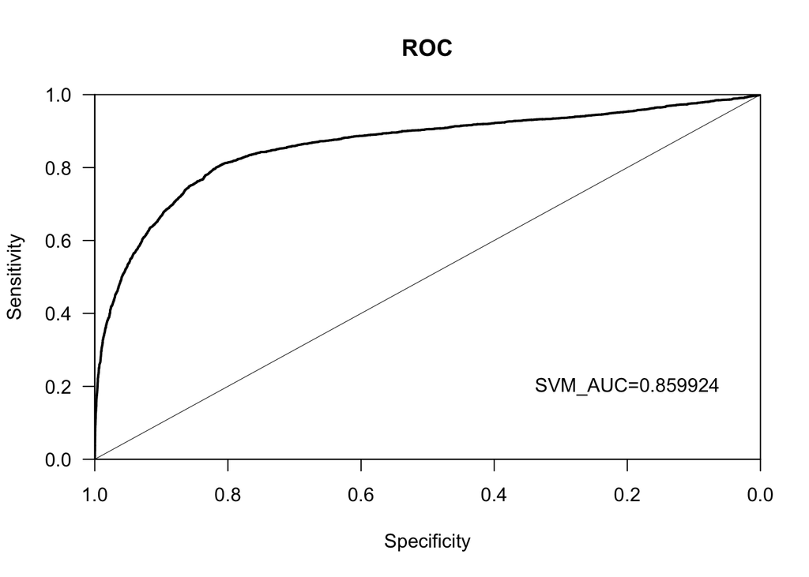

```r
svm_auc <- auc(svm_roc_obj)

plot.new()
plot.window(xlim = c(1,0),ylim = c(0,1),xaxs='i',yaxs='i')
axis(1,las=1)
axis(2,las=1)
abline(1,-1,col="black",lwd=0.5)
box()
title(main="ROC",xlab = "Specificity",ylab = "Sensitivity")
lines(svm_roc_obj,col="black",las=2)
text(x=0.2,y=0.2,paste("SVM_AUC=",round(svm_auc,6),sep = ''))
```

Change Target variable back to numeric.

```r
impweather2$RainTomorrow<-as.numeric(impweather2$RainTomorrow)
str(impweather2$RainTomorrow)
```

```
##  num [1:50778] 1 1 1 1 1 1 1 1 1 1 ...
```

```r
table(impweather2$RainTomorrow)
```

```
##
##     1     2
## 39577 11201
```

```r
impweather2$RainTomorrow <-ifelse(impweather2$RainTomorrow==2,1,0)
table(impweather2$RainTomorrow)
```

```
##
##     0     1
## 39577 11201
```

## Naive Bayes

Setting up required libraries.

```r
library(e1071)
library(caret)
library(magrittr)
library(dplyr)
```

Generalization phase for NaiveBayes with the entire data.

```r
nbtr.model1<-naiveBayes(RainTomorrow~.,data=impweather2)
nbtr.model1
```

```
##
## Naive Bayes Classifier for Discrete Predictors
##
## Call:
## naiveBayes.default(x = X, y = Y, laplace = laplace)
##
## A-priori probabilities:
## Y
##         0         1
## 0.7794123 0.2205877
##
## Conditional probabilities:
##    Humidity3pm
## Y       [,1]     [,2]
##   0 44.75817 17.84714
##   1 66.98268 18.37306
##
##    Sunshine
## Y       [,1]     [,2]
##   0 8.633494 3.341537
##   1 4.537265 3.385280
##
##    Pressure3pm
## Y       [,1]     [,2]
##   0 1015.629 6.539330
##   1 1011.822 7.144908
##
##    WindGustSpeed
## Y       [,1]     [,2]
##   0 39.22260 12.16125
##   1 46.72574 15.38879
##
##    Cloud3pm
## Y       [,1]     [,2]
##   0 3.784446 2.586507
##   1 6.260066 1.844379
##
##    Rainfall
## Y       [,1]      [,2]
##   0 1.194087  4.666261
```

[output cut: 31 more lines]

```
##
##    Location
## Y       [,1]     [,2]
##   0 13.62443 7.371590
##   1 13.56638 7.020244
##
##    Cloud9am
## Y       [,1]     [,2]
##   0 3.765874 2.765261
##   1 5.950272 2.160012
##
##    WindDir9am
## Y       [,1]     [,2]
##   0 8.039771 4.686032
##   1 8.437372 4.555004
```

```r
nbtr.pred<-predict(nbtr.model1,impweather2[,-c(16)],type='raw')
nbtr.class<-unlist(apply(round(nbtr.pred),1,which.max))-1
nbtr.tbl<-table(impweather2[[16]], nbtr.class)
cfm<-caret::confusionMatrix(nbtr.tbl)
cfm
```

```
## Confusion Matrix and Statistics
##
##    nbtr.class
##         0     1
##   0 33049  6528
##   1  3565  7636
##
##                Accuracy : 0.8012
##                  95% CI : (0.7977, 0.8047)
##     No Information Rate : 0.7211
##     P-Value [Acc > NIR] : < 2.2e-16
##
##                   Kappa : 0.472
##
##  Mcnemar's Test P-Value : < 2.2e-16
##
##             Sensitivity : 0.9026
##             Specificity : 0.5391
##          Pos Pred Value : 0.8351
##          Neg Pred Value : 0.6817
##              Prevalence : 0.7211
##          Detection Rate : 0.6509
##    Detection Prevalence : 0.7794
##       Balanced Accuracy : 0.7209
##
##        'Positive' Class : 0
##
```

Checking dimension for training and test data.

```r
dim(trdata)
```

```
## [1] 35545    16
```

```r
table(trdata$RainTomorrow)
```

```
##
##     0     1
## 27770  7775
```

```r
dim(tsdata)
```

```
## [1] 15233    16
```

```r
table(tsdata$RainTomorrow)
```

```
##
##     0     1
## 11807  3426
```

Training the model over Training data and find resulting Training accuracies.

```r
nbtr.model<-naiveBayes(RainTomorrow~.,data=trdata)

nbtr.trpred<-predict(nbtr.model,trdata[,-c(16)],type='raw')
nbtr.trclass<-unlist(apply(round(nbtr.trpred),1,which.max))-1
nbtr.trtbl<-table(trdata[[16]], nbtr.trclass)
tr.cfm<-caret::confusionMatrix(nbtr.trtbl)
tr.cfm
```

```
## Confusion Matrix and Statistics
##
##    nbtr.trclass
##         0     1
##   0 23272  4498
##   1  2485  5290
##
##                Accuracy : 0.8035
##                  95% CI : (0.7994, 0.8077)
##     No Information Rate : 0.7246
##     P-Value [Acc > NIR] : < 2.2e-16
##
##                   Kappa : 0.4742
##
##  Mcnemar's Test P-Value : < 2.2e-16
##
##             Sensitivity : 0.9035
##             Specificity : 0.5405
##          Pos Pred Value : 0.8380
##          Neg Pred Value : 0.6804
##              Prevalence : 0.7246
##          Detection Rate : 0.6547
##    Detection Prevalence : 0.7813
##       Balanced Accuracy : 0.7220
##
##        'Positive' Class : 0
##
```

Using the Training model over test data to find Test accuracies.

```r
nbtr.tspred<-predict(nbtr.model,tsdata[,-c(16)],type='raw')

roc.nbtr.tspred<-nbtr.tspred[,2]
nbtr.tsclass<-unlist(apply(round(nbtr.tspred),1,which.max))-1
nbtr.tstbl<-table(tsdata[[16]], nbtr.tsclass)
tst.cfm<-caret::confusionMatrix(nbtr.tstbl)
tst.cfm
```

```
## Confusion Matrix and Statistics
##
##    nbtr.tsclass
##        0    1
##   0 9825 1982
##   1 1104 2322
##
##                Accuracy : 0.7974
##                  95% CI : (0.7909, 0.8038)
##     No Information Rate : 0.7175
##     P-Value [Acc > NIR] : < 2.2e-16
##
##                   Kappa : 0.4674
##
##  Mcnemar's Test P-Value : < 2.2e-16
##
##             Sensitivity : 0.8990
##             Specificity : 0.5395
##          Pos Pred Value : 0.8321
##          Neg Pred Value : 0.6778
##              Prevalence : 0.7175
##          Detection Rate : 0.6450
##    Detection Prevalence : 0.7751
##       Balanced Accuracy : 0.7192
##
##        'Positive' Class : 0
##
```

```r
nb_tst_accuracy <- tst.cfm$overall['Accuracy']
```

## KNN

We implement KNN from the “class” library. Setting up required libraries.

```r
library(class)
library(ROCR)
```

We set the dataframe, labelcolumn which we wish to predict.

```r
knn.df<-impweather2
knn.ids <- sample(1:nrow(knn.df),nrow(knn.df),replace = F)
knn.df <- knn.df[knn.ids,]
labelcol <- 16
```

Dividing the dataframe into test and training dataframes.

```r
set.seed(43)
n<-nrow(knn.df)
knn.df<- knn.df[sample(n),]

train.df <- knn.df[1:as.integer(0.7*n),]
test.df <- knn.df[as.integer(0.7*n +1):n,]
```

Since KNN calculates distances, we convert our labelcolumn to factor.

```r
cl<-factor(train.df[,16])
```

Running the KNN classifier with K=12, We tried the classifier with diifferent values of K from K=4 to K=15, and K=12 seems to provide with consistent accuracy.

```r
knnPred<-knn(train.df[,-c(labelcol)],test.df[,-c(labelcol)], cl, k = 12, prob=TRUE)
prob<-attr(knnPred,"prob")
kp<-prediction(prob,test.df[,labelcol])
AUC<-performance(kp,"auc")
#perf <- performance(pred,"tpr","fpr")
#plot(perf,colorize=TRUE)

pred_knn<-performance(kp,"tpr","fpr")
```

Plotting the AUC curve.

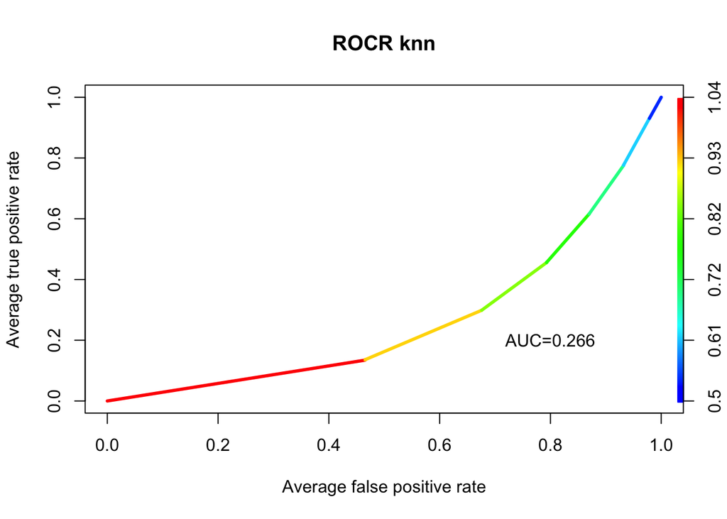

```r
plot(pred_knn,avg="threshold",colorize=T,lwd=3,main="ROCR knn")
text(0.8,0.2,paste("AUC=",round(AUC@y.values[[1]],4),sep=''))
```

```r
TBL<-table(test.df[,labelcol],knnPred)
print(paste("accuracy=",sum(diag(TBL))/sum(TBL)))
```

```
## [1] "accuracy= 0.850334777471445"
```

```r
knn_accuracy <- sum(diag(TBL))/sum(TBL)
```

## Multinomial Logistic Regression

We will run the multinom function from nnet library.

```r
library(nnet)

multinom_model<-multinom("RainTomorrow~.",data=impweather2)
multinom_model
```

```
## Call:
## multinom(formula = "RainTomorrow~.", data = impweather2)
##
## Coefficients:
##   (Intercept)   Humidity3pm      Sunshine   Pressure3pm WindGustSpeed
##  62.025829466   0.057249617  -0.149475677  -0.067398322   0.058322362
##      Cloud3pm      Rainfall   Humidity9am       MinTemp       MaxTemp
##   0.107632734   0.021043562   0.003087558  -0.035641960   0.052740499
##   Evaporation  WindSpeed3pm  WindSpeed9am      Location      Cloud9am
##  -0.028820815  -0.025818087  -0.014738200  -0.004078261  -0.023006652
##    WindDir9am
##  -0.011540702
##
## Residual Deviance: 34321.86
## AIC: 34353.86
```

The model is ready for the generalization phase. Now we test our model by predicting class values and comparing with actual values.

```r
multinom_pred<-predict(multinom_model,impweather2[,-16],type="class")
mncfm<-caret::confusionMatrix(table(impweather2[,16],multinom_pred))
mncfm
```

```
## Confusion Matrix and Statistics
##
##    multinom_pred
##         0     1
##   0 37348  2229
##   1  5260  5941
##
##                Accuracy : 0.8525
##                  95% CI : (0.8494, 0.8556)
##     No Information Rate : 0.8391
##     P-Value [Acc > NIR] : < 2.2e-16
##
##                   Kappa : 0.525
##
##  Mcnemar's Test P-Value : < 2.2e-16
##
##             Sensitivity : 0.8765
##             Specificity : 0.7272
##          Pos Pred Value : 0.9437
##          Neg Pred Value : 0.5304
##              Prevalence : 0.8391
##          Detection Rate : 0.7355
##    Detection Prevalence : 0.7794
##       Balanced Accuracy : 0.8019
##
##        'Positive' Class : 0
##
```

Above mentioned are the results for Generalization phase. The model seems to work satisfactorily. Now we run the multinom model on training data and check training accuracy.

```r
multinom_trmodel<-multinom("RainTomorrow~.",data=trdata)
multinom_trpred<-predict(multinom_trmodel,trdata[,-16],type="class")
mntrcfm<-caret::confusionMatrix(table(trdata[,16],multinom_trpred))
mntrcfm
```

```
## Confusion Matrix and Statistics
##
##    multinom_trpred
##         0     1
##   0 26233  1537
##   1  3659  4116
##
##                Accuracy : 0.8538
##                  95% CI : (0.8501, 0.8575)
##     No Information Rate : 0.841
##     P-Value [Acc > NIR] : 1.084e-11
##
##                   Kappa : 0.5257
##
##  Mcnemar's Test P-Value : < 2.2e-16
##
##             Sensitivity : 0.8776
##             Specificity : 0.7281
##          Pos Pred Value : 0.9447
##          Neg Pred Value : 0.5294
##              Prevalence : 0.8410
##          Detection Rate : 0.7380
##    Detection Prevalence : 0.7813
##       Balanced Accuracy : 0.8029
##
##        'Positive' Class : 0
##
```

We now use the model created using training data on our test data.

```r
multinom_tspred<-predict(multinom_trmodel,tsdata[,-16],type="class")
mntscfm<-caret::confusionMatrix(table(tsdata[,16],multinom_tspred))
```

Accuracy measures for Multinom are as follows

```r
mntscfm
```

```
## Confusion Matrix and Statistics
##
##    multinom_tspred
##         0     1
##   0 11143   664
##   1  1620  1806
##
##                Accuracy : 0.8501
##                  95% CI : (0.8443, 0.8557)
##     No Information Rate : 0.8379
##     P-Value [Acc > NIR] : 1.913e-05
##
##                   Kappa : 0.5227
##
##  Mcnemar's Test P-Value : < 2.2e-16
##
##             Sensitivity : 0.8731
##             Specificity : 0.7312
##          Pos Pred Value : 0.9438
##          Neg Pred Value : 0.5271
##              Prevalence : 0.8379
##          Detection Rate : 0.7315
##    Detection Prevalence : 0.7751
##       Balanced Accuracy : 0.8021
##
##        'Positive' Class : 0
##
```

```r
mn_tst_accuracy <- mntscfm$overall['Accuracy']
```

## Plotting the Accuracies obtained from different classifiers.

We have accuracies obtained from the test data evaluation. The Classifiers used include Logistic Regression, SVM, Naive Bayes, KNN and Multinomial Logistic Regression. The below plot shows their accuracy comparison.

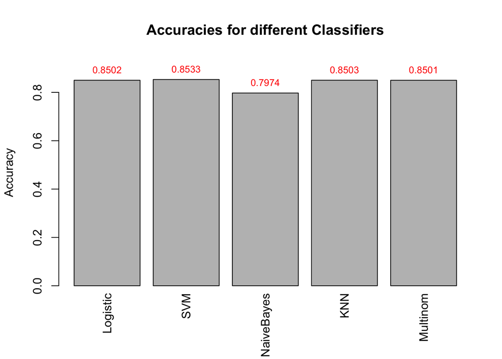

```r
accuracy_values <- c(lgr_tst_accuracy,svm_tst_accuracy,nb_tst_accuracy,knn_accuracy,mn_tst_accuracy)
accuracy_values <- round(accuracy_values,4)
names(accuracy_values) <- c("Logistic","SVM","NaiveBayes","KNN","Multinom")

ylim <- c(0, 1.1*max(accuracy_values))
## Plot, and store x-coordinates of bars in xx
xx <- barplot(accuracy_values, xaxt = 'n', xlab = '', width = 0.85, ylim = ylim,
              main = "Accuracies for different Classifiers",
              ylab = "Accuracy")
## Add text at top of bars
text(x = xx, y = accuracy_values, label = accuracy_values, pos = 3, cex = 0.8, col = "red")
## Add x-axis labels
axis(1, at=xx, labels=names(accuracy_values), tick=FALSE, las=2, line=-0.5)
```

## Variance Estimation

We use the invisible() to hide unnecessary computation values generated while running the model over 100 times.

```r
invisible({capture.output({

library(nnet)
library(e1071)
library(class)
library(caret)
library(magrittr)
library(dplyr)
library(class)



varianceEstimator = function(tr,ts,percent,classifier){

  targetid = which(names(tr)=="RainTomorrow")
  var_accuracy=c();


  for(i in 1:100){
    var_trid=sample(1:nrow(tr),percent/100*nrow(tr),replace=F)
    var_tr=tr[var_trid,]
    if(classifier=="SVM"){

      svm_model_var = svm(RainTomorrow~.,data=var_tr,probability=TRUE)
      pred_var = predict(svm_model_var,ts[,-c(16)],probability = TRUE)


    }else if(classifier=="NaiveBayes"){

      nb_model_var = multinom("RainTomorrow~.",data=var_tr)
      pred_var = predict(multinom_model,ts[,-16],type="class")

    }else if(classifier=="KNN"){

      labelcol <- 16
      cl<-factor(var_tr[,16])
      pred_var<-knn(var_tr[,-c(labelcol)],ts[,-c(labelcol)], cl, k = 12, prob=TRUE)

    }else if(classifier=="Multinom"){

      mn_model_var<-multinom("RainTomorrow~.",data=var_tr)
      pred_var<-predict(mn_model_var,ts[,-16],type="class")

    }else{
      print("Enter valid classifier")
    }

    u_var=union(pred_var,ts[,targetid])
    t_var=table(factor(pred_var,u_var),factor(ts[,targetid],u_var))
    cfm_var=caret::confusionMatrix(t_var)
    cfm_var_accuracy=cfm_var$overall[["Accuracy"]]

    var_accuracy=c(var_accuracy,cfm_var_accuracy)
  }

  mean_var=signif(mean(var_accuracy),4)
  var_var=signif(var(var_accuracy),4)
  var=data.frame(mean_var,var_var)
  names(var)=c("Accuracy mean","Accuracy variance")
  return(t(var))
}

#Classifier = "SVM" or "NaiveBayes" or "KNN" or "Multinom"

#Testing function for Multinom
var_est_20 = varianceEstimator(impweather2,vardata,20,classifier = "Multinom")
var_est_30 = varianceEstimator(impweather2,vardata,30,classifier = "Multinom")
var_est_50 = varianceEstimator(impweather2,vardata,50,classifier = "Multinom")


})})
```

```r
print("Accuracy mean and variance for 20 percent training data")
```

```
## [1] "Accuracy mean and variance for 20 percent training data"
```

```r
var_est_20
```

```
##                        [,1]
## Accuracy mean     8.534e-01
## Accuracy variance 1.065e-06
```

```r
print("Accuracy mean and variance for 30 percent training data")
```

```
## [1] "Accuracy mean and variance for 30 percent training data"
```

```r
var_est_30
```

```
##                        [,1]
## Accuracy mean     8.537e-01
## Accuracy variance 8.307e-07
```

```r
print("Accuracy mean and variance for 50 percent training data")
```

```
## [1] "Accuracy mean and variance for 50 percent training data"
```

```r
var_est_50
```

```
##                        [,1]
## Accuracy mean     8.539e-01
## Accuracy variance 6.811e-07
```